# HOMEWORK 4

KIM DONGWON

2020 5 7

예제 1. 주어진 자료는 전체 부동산에 대한 자료이므로 모집단으로 생각할 수 있다. 거래가 이루어진 전체 부동산의 집의 크기의 평균값은 얼마인가? 모분산은 얼마인가?

```r
ames<-read.csv("C:/Users/r english/Desktop/r/ames.csv", header= T)
mean(ames$Gr.Liv.Area)
```

```
## [1] 1499.69
```

```r
V<-var(ames$Gr.Liv.Area)*(length(ames$Gr.Liv.Area-1)/length(ames$Gr.Liv.Area))
print(V)
```

```
## [1] 255539.2
```

예제 2. 모집단에서 크기가 60인 랜덤 표본을 선택하자. 모집단 평균에 대한 점추정값은 얼마 인가?

```r
sam_ams<-sample(ames$Gr.Liv.Area,60)
mean(sam_ams)
```

```
## [1] 1475.333
```

예제 3. 예제 2에서 선택된 표본을 이용하여 모평균에 대한 95% 신뢰구간을 구해보자. 이 때, 모분산은 예제 1에서 구한 값을 사용하도록 한다. 이 신뢰구간은 모평균을 포함하는가?

```r
A<-mean(sam_ams)+1.96*(sqrt(V/60));
B<-mean(sam_ams)-1.96*(sqrt(V/60));
if ( (B < mean(ames$Gr.Liv.Area)) & ( mean(ames$Gr.Liv.Area)) <A ) {print("이 신뢰구간은 모평균을 포함한다")};
```

```
## [1] "이 신뢰구간은 모평균을 포함한다"
```

예제 4. 예제 3과 동일한 과정을 50번 반복하여 서로 다른 신뢰구간 50개를 구해보자. 이 때, 신뢰구간의 하한값을 lower 벡터에 각각 저장하고 신뢰구간의 상한값은 upper 벡터에 각각 저장하도록 한다. 예제 1에서 구한 모평균의 값은 pop.mean에 저장한다. 그리고 아래의 코드를 실행해보자. 출력된 그래프가 나타내는 실제 신뢰수준은 어떠한가?

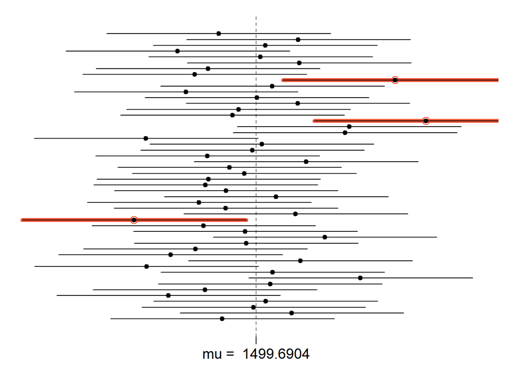

```r
sample_mean<-c();
for (i in 1:50){  x<-sample(ames$Gr.Liv.Area,60)
sample_mean[i]<-mean(x)
upper<-sample_mean+1.96*(sqrt(V/60));  lower<-sample_mean-1.96*(sqrt(V/60)) }
pop.mean<-mean(ames$Gr.Liv.Area)

plot_ci <- function(lo, hi, m) {
  par(mar=c(2, 1, 1, 1), mgp=c(2.7, 0.7, 0))
  k <- length(lo)
  ci.max <- max(rowSums(matrix(c(-1*lo,hi),ncol=2)))
  xR <- m + ci.max*c(-1, 1)
  yR <- c(0, 41*k/40)
  plot(xR, yR, type='n', xlab='', ylab='', axes=FALSE)
  abline(v=m, lty=2, col='#00000088')
  axis(1, at=m, paste("mu = ",round(m,4)), cex.axis=1.15)

 for(i in 1:k) {
    x  <- mean(c(hi[i], lo[i]))
    ci <- c(lo[i], hi[i])
    if (lo[i] > m | m > hi[i]) {
      col <- "#F05133"
      points(x, i, cex = 1.4, col = col)
      lines(ci, rep(i, 2), col = col, lwd = 5)
    }
    col <- 1
    points(x, i, pch = 20, cex = 1.2, col = col)
    lines(ci, rep(i, 2), col = col)
  }
}
plot_ci(lower, upper, pop.mean)
```

코드를 실행시켰을 때 많은 경우에서 50개중 2~3개의 신뢰구간에서 모평균을 포함하지 않는것으로 보아 신뢰구간은 약 95%이다.

dev.off()

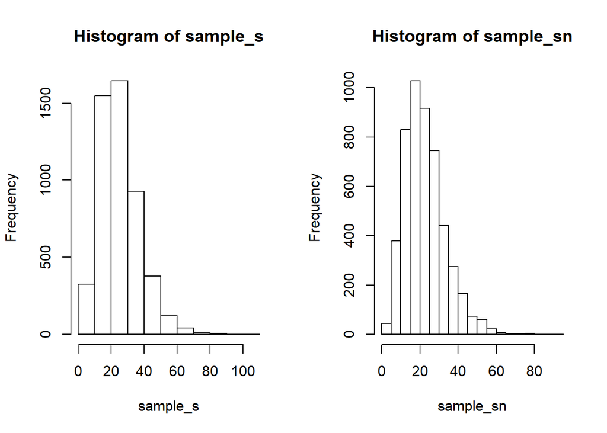

```r
par(mfrow=c(1,2))
sample_s<-c();sample_sn<-c();
for (i in 1:5000) {x<-rnorm(10,0,5)
sample_s[i]<-var(x)
sample_sn[i]<-var(x)*9/10
}
hist(sample_s)
hist(sample_sn)
```

```r
mean(sample_s)
```

```
## [1] 25.19801
```

```r
mean(sample_sn)
```

```
## [1] 22.67821
```

```r
#모분산은 25
```

그 이유를 유추해보자면 분모를 n-1로 나누는 이유는 분산을 계산할 때 모평균이 아닌 표본 평균을 사용했기 때문에 모집단의 편의된 추정값이 되므로, 분산이 불편 추정량이 되도록 하기 위해서이다.

[7~9] 어느 과자 회사가 자사에서 파는 제품의 총 내용량은 평균 200g이라고 주장하 고 있다. 한편, 제품 30개를 임의로 추출하여 각각 실제 내용량을 조사한 결과가 다 음과 같았다. 204.6, 189.7, 186.8, 215.4, 205.1, 206.6, 191.1, 209.9, 191.6, 206.3, 203.6, 189.8, 207.9, 205.1, 178.8, 177.4, 199.1, 193.8, 205.9, 191.0, 199.1, 208.9, 187.9, 194.5, 197.1, 198.5, 208.5, 192.9, 212.8, 173.9 이때, 제품의 총 내용량이 정규분포를 따르고 표준편차는 10으로 알고 있다고 가정한다.

7. 회사의 주장이 과장인지를 조사하기 위해. 실제 내용량이 200g보다 적다고 할 수 있는지 검정하고자 한다. 귀무가설과 대립가설을 세우고, 검정통계량과 유의확률을 구 하여 각각 적절한 오브젝트에 저장하고 출력하시오.

```r
#귀무가설: 실제 내용량이 200g이다
#대립가설: 실제 내용량이 200보다 적다.
x7<-c( 204.6, 189.7, 186.8, 215.4, 205.1, 206.6, 191.1, 209.9, 191.6, 206.3, 203.6, 189.8, 207.9, 205.1, 178.8, 177.4, 199.1, 193.8, 205.9, 191.0, 199.1, 208.9, 187.9, 194.5, 197.1, 198.5, 208.5, 192.9, 212.8, 173.9 )
mu<-200
sigma<- 10
x.bar<-mean(x7)
n<-30
Z<-(x.bar-mu)/(sigma/sqrt(n)) #검정통계량
P<-pnorm(x.bar,200,10/sqrt(n)) #유의확률
print(Z)
```

```
## [1] -1.212293
```

```r
print(P)
```

```
## [1] 0.1127002
```

8. 유의수준 0.05에서 검정 결과를 다음 두 조건 중 하나를 활용하여 if문과 print 를 통해 출력하시오. (두 조건은 서로 동치이다.) (1) 검정통계량이 기각역에 속하면 귀무가설 기각, 아니면 기각하지 못함 (2) 유의확률이 유의수준보다 작으면 귀무가설 기각, 아니면 기각하지 못함

```r
x7<-c( 204.6, 189.7, 186.8, 215.4, 205.1, 206.6, 191.1, 209.9, 191.6, 206.3, 203.6, 189.8, 207.9, 205.1, 178.8, 177.4, 199.1, 193.8, 205.9, 191.0, 199.1, 208.9, 187.9, 194.5, 197.1, 198.5, 208.5, 192.9, 212.8, 173.9 )
mu<-200
sigma<- 10
x.bar<-mean(x7)
n<-30
z_alpha<-qnorm(0.05)
Z<- (x.bar-mu)/(sigma/sqrt(n))
if(Z<z_alpha){print("귀무가설을 기각한다")} else{print("귀무가설을 기각하지 않는다")}
```

```
## [1] "귀무가설을 기각하지 않는다"
```

9. 가설 검정에서 유의확률은 귀무가설이 참일 때 표본을 통해 얻은 결과보다 더 극단적인 결과가 나올 확률을 뜻한다. 유의확률의 의미를 나타내는 시뮬레이션을 다음 과정을 통해 시행하시오. (시뮬레이션 결과, 예제 7의 유의확률에 근사함을 알 수 있다.)
1. 오브젝트 count에 0을 저장.
2. 예제 7의 귀무가설에 해당하는 분포에서 30개의 표본을 생성하고, 이들을 활용하여 검정통계량을 계산.
3. (2)의 검정통계량이 예제 7의 검정통계량보다 작으면(즉, 더 극단적이면) count에 1을 더하여 다시 count에 저장.
4. (2)~(3)의 과정을 10000번 반복하고, 최종적으로 count/10000을 출력.

```r
mu<-200
sigma<- 10
n<-30

count<-0 #1

A<-rnorm(n,mu,sigma)
x.bar9<-mean(A)
Z9<-(x.bar9-mu)/(sigma/sqrt(n))#2

if(Z9<Z) {count=count+1} #3


for (i in 1:10000) {
  A<-rnorm(n,mu,sigma)
x.bar9<-mean(A)

Z9<-(x.bar9-mu)/(sigma/sqrt(n))
if(Z9<Z) {count=count+1}
}
print(count/10000) #4
```

```
## [1] 0.1142
```

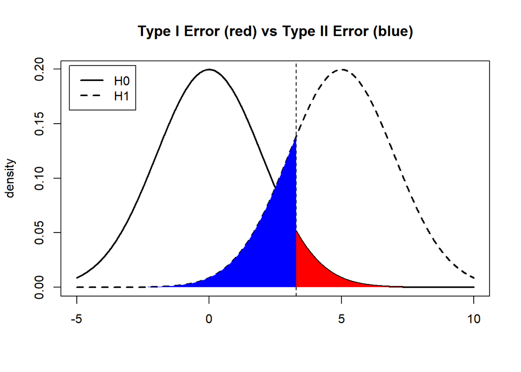

```r
par(mfrow = c(1,1))
## 필요한 경우 다음 오브젝트 활용
mu0 <- 0 ;mu1 <- 5; sigma <- 2
## 귀무가설(H0) 분포 그래프 그리기
y1 <- seq(-5, 10, 0.01)
fy1 <- dnorm(y1,0,2)
  plot(y1, fy1, type = "l", lwd = 2, lty = 1,     xlab = "", ylab = "density",     main = "Type I Error (red) vs Type II Error (blue)")
## 대립가설(H1) 분포 그래프 추가하기
  y2 <- seq(-5, 10, 0.01)
  fy2 <- dnorm(y2,5,2)
lines(y2, fy2, lwd = 2, lty = 2)
legend("topleft", c("H0","H1"), lwd = 2, lty = c(1,2), inset = 0.02) # 그래프 주석
qu <- qnorm(0.95, mu0, sigma)   # 제 1종 오류가 0.05가 되도록 경계 설정
abline(v = qu, lty = 2)  # 세로선 추가
## 제1종 오류 확률 나타내기
z1 <- seq(qu, 10, 0.01)
fz1 <-dnorm(z1,0,2)
polygon(c(qu, z1), c(0, fz1), col="red", border=NA)
## 제2종 오류 확률 나타내기
z2 <- seq(-5, qu, 0.01)
fz2 <-dnorm(z2,5,2)
polygon(c(qu, z2), c(0, fz2), col="blue", border=NA)
```